# Translate viral load and PCR efficiency to test sensitivity at different dilutions

The RT-qPCR process leads to an exponential growth phase of the viral load, such that after some number of cycles $n$, the viral load $R_n$ will be a function of the efficiency of the reaction $E$, the dilution factor and the starting viral load in the sample $R_0$:

$$R_n = \frac{R_0}{D}(1 + E)^n$$

Let the probability of a positive case being detected be 0.98 for an undiluted sample, and 0.8 for a 10x diluted sample. Allow up to $C_T = 35$ cycles to reach some fluourescence detection threshold $R_{C_T}. Let $R_0$ be distributed in the population such that

$$R_0 \sim 10^{U(0, 3)}$$

and assume that efficiency is some distribution between 0.65 and 0.9 e.g.

$$E ~ \sim Beta(\alpha, \beta) \times (0.9 - 0.65) + 0.65$$

Simulate some values of $E$ and $R_0$

```r
set.seed(12345)
library(scales)
library(dplyr)
```

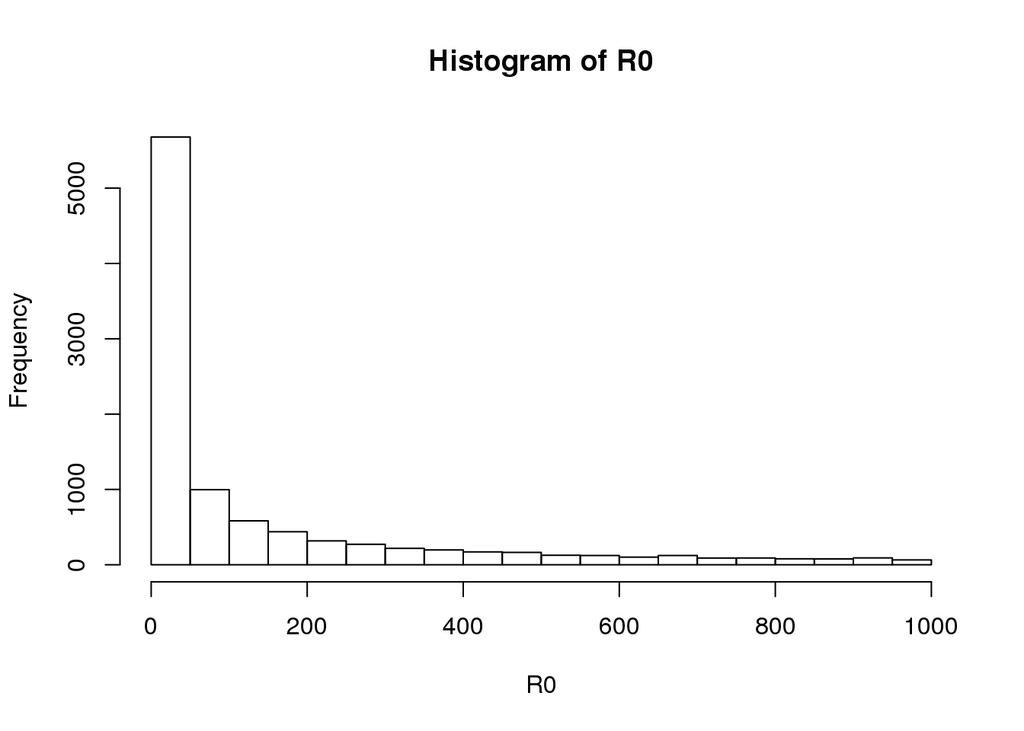

```r
n <- 10000
R0 <- 10^runif(n, 0, 3)
E <- rbeta(n, 2, 5) %>% rescale(., to=c(0.65, 0.9))
hist(R0)
```

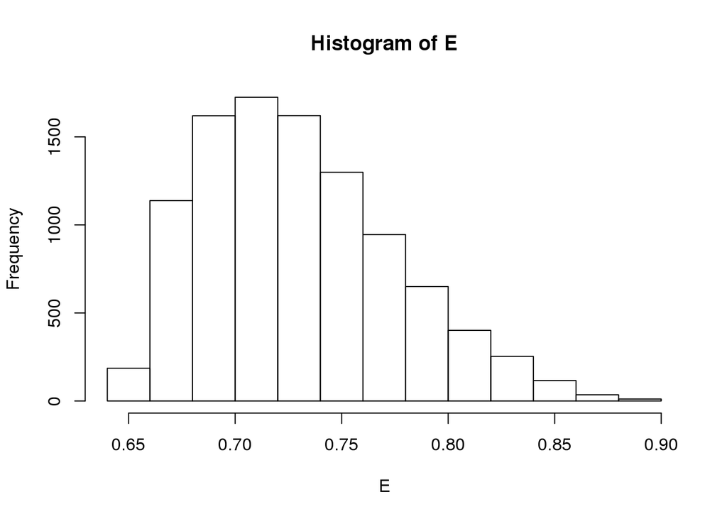

```r
hist(E)
```

Calculate the $R_{C_T}$ values for different dilutions

```r
R35_1 <- R0 * (1 + E)^35
R35_10 <- R0/10 * (1 + E)^35
R35_30 <- R0/30 * (1 + E)^35
```

Are the sensitivities at the different dilutions concordant?

```r
(quantile(log(R35_1), 0.02) - quantile(log(R35_10), 0.2))^2
```

```
##        2%
## 0.1844758
```

Quite similar. What sort of dilution curve does this give us?

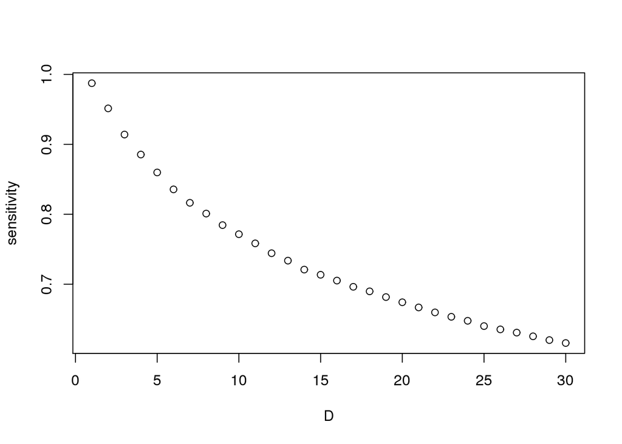

```r
D <- seq(1,30)
Rct <- mean(c(
    quantile(log(R35_1), 0.02),
    quantile(log(R35_10), 0.2)
))
dat <- tibble(
    D=D,
    sensitivity=sapply(D, function(x)
    {
        sum(log(R0/x * (1 + E)^35) > Rct)/n
    })
)
plot(sensitivity ~ D, dat)
```

Use optimisation to find parameters that will give concordant sensitivities at D = 1 and 10

```r
fn <- function(param, R0)
{
    n <- length(R0)
    E <- rbeta(n, param[1], param[2]) * (0.9-0.65) + 0.65
    R35_1 <- R0 * (1 + E)^35
    R35_10 <- R0/10 * (1 + E)^35
    q1 <- quantile(log(R35_1), 0.02, na.rm=TRUE)
    q10 <- quantile(log(R35_10), 0.2, na.rm=TRUE)
    return((q1 - q10)^2)
}
fn(c(2,5), R0)
```

```
##        2%
## 0.3064208
```

```r
n <- 100000
R0 <- 10^runif(n, 0, 3)
o <- optim(par = c(2, 5), fn=fn, R0=R0)
o
```

```
## $par
## [1] 2.5880577 0.9795588
##
## $value
## [1] 4.684844e-08
##
## $counts
## function gradient
##      299       NA
##
## $convergence
## [1] 10
##
## $message
## NULL
```

Now that we have parameter values for the distribution of $E$ we can generate the dilution curve

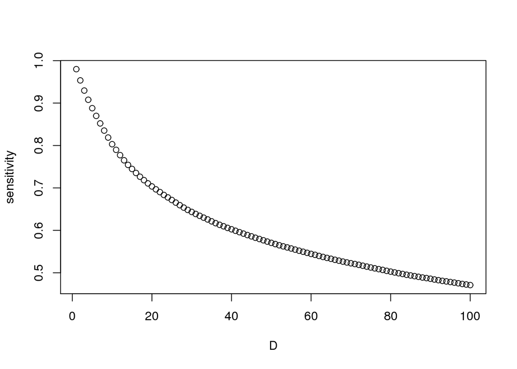

```r
D <- seq(1,100)
E <- rbeta(n, o$par[1], o$par[2]) * (0.9-0.65) + 0.65
Rct <- quantile(log(R0 * (1 + E)^35), 0.02)
dat <- tibble(
    D=D,
    sensitivity=sapply(D, function(x)
    {
        sum(log(R0/x * (1 + E)^35) > Rct)/n
    })
)
plot(sensitivity ~ D, dat)
```

## Fitting realistic Ct values

The above leads to unrealistic Ct distributions. Change approach - generate viral load by simulating Ct values first. Need to find distributions of Ct and E that are reasonable, and give appropriate sensitivities at dilutions of 1x and 10x

- 1x dilution sensitivity = 0.983
- 10x dilution sensitivity = 0.8

See https://www.ncbi.nlm.nih.gov/pmc/articles/PMC7454307/ Figure 3 for distribution of Ct values

```r
set.seed(12345)

n <- 500000
rct <- 10
ctthresh <- 35
e_max <- 1.4
e_min <- 0.9
e_alpha <- 2
e_beta <- 4
sensitivity_1 <- 0.983
tpr1 <- 0.983
tpr10 <- 0.8

est_rct <- function(r0, ctmax, E)
{
    r0 * (1 + E)^ctmax
}

est_r0 <- function(ct, E, rct)
{
    rct / (1+E)^ct
}

est_ct <- function(r0, E, rct)
{
    log(rct/r0) / log(1+E)
}

get_ct <- function(n, uci, lci, ct_alpha=1.1, ct_beta=1.1)
{
    rbeta(n, ct_alpha, ct_beta) * (uci-lci) + lci
}

get_E <- function(n, uci, lci, perc=0.99)
{
    mu <- mean(c(uci, lci))
    s <- (mu - lci) / qnorm(perc)
    rnorm(100000, mu, s) %>% pmax(., 0) %>% pmin(., 1)
}

fn <- function(param, n, rct, e_max, e_min, ctthresh, tpr1=tpr1, tpr10=tpr10)
{
    ctd <- get_ct(n, param[1], param[2], param[3], param[4])
    Ed <- rbeta(n, param[5], param[6]) * (e_max-e_min) + e_min
    r0 <- est_r0(ctd, Ed, rct)
    r0_10 <- r0 / 10
    ctd_10 <- est_ct(r0_10, Ed, rct)
    s1 <- sum(ctd < ctthresh)/n
    s10 <- sum(ctd_10 < ctthresh)/n
    return((s1 - tpr1)^2 + (s10 - tpr10)^2)
}

(efficiency_params <- optim(par = c(35, 15, 1.1, 1.1, 1, 1), fn=fn, n=n, rct=rct, e_max=e_max, e_min=e_min, ctthresh=ctthresh, tpr1=tpr1, tpr10=tpr10, control=list(maxit=1000)))
```

```
## $par
## [1] 35.457963 15.822604  1.647962  1.234565  1.747571  1.976305
##
## $value
## [1] 1.0132e-08
##
## $counts
## function gradient
##      767       NA
##
## $convergence
## [1] 10
##
## $message
## NULL
```

```r
ctd <- get_ct(n, efficiency_params$par[1], efficiency_params$par[2], efficiency_params$par[3], efficiency_params$par[4])
Ed <- rbeta(n, efficiency_params$par[5], efficiency_params$par[6]) * (e_max-e_min) + e_min
r0 <- est_r0(ctd, Ed, rct)
r0_10 <- r0 / 10
ctd_10 <- est_ct(r0_10, Ed, rct)
s1 <- sum(ctd < ctthresh)/n
s10 <- sum(ctd_10 < ctthresh)/n

sum(ctd < ctthresh) / n
```

```
## [1] 0.983202
```

```r
sum(ctd_10 < ctthresh) / n
```

```
## [1] 0.801198
```

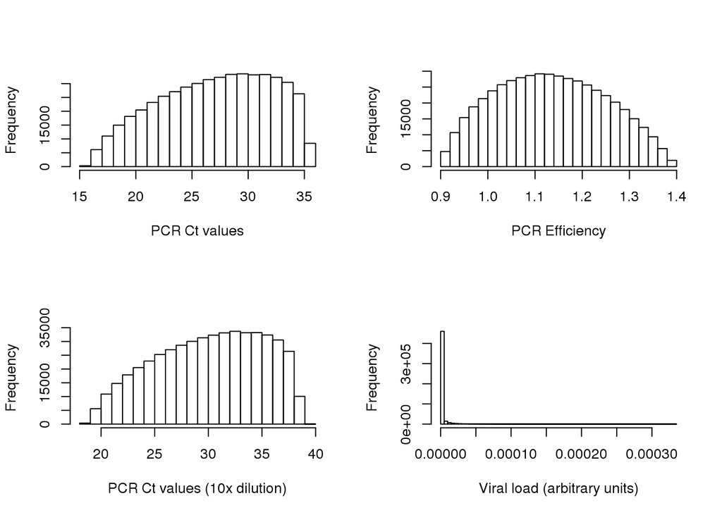

```r
par(mfrow=c(2,2))
hist(ctd, main="", xlab="PCR Ct values")
hist(Ed, main="", xlab="PCR Efficiency")
hist(ctd_10, main="", xlab="PCR Ct values (10x dilution)")
hist(r0, breaks=100, main="", xlab="Viral load (arbitrary units)")
```

Change in sensitivity over dilutions

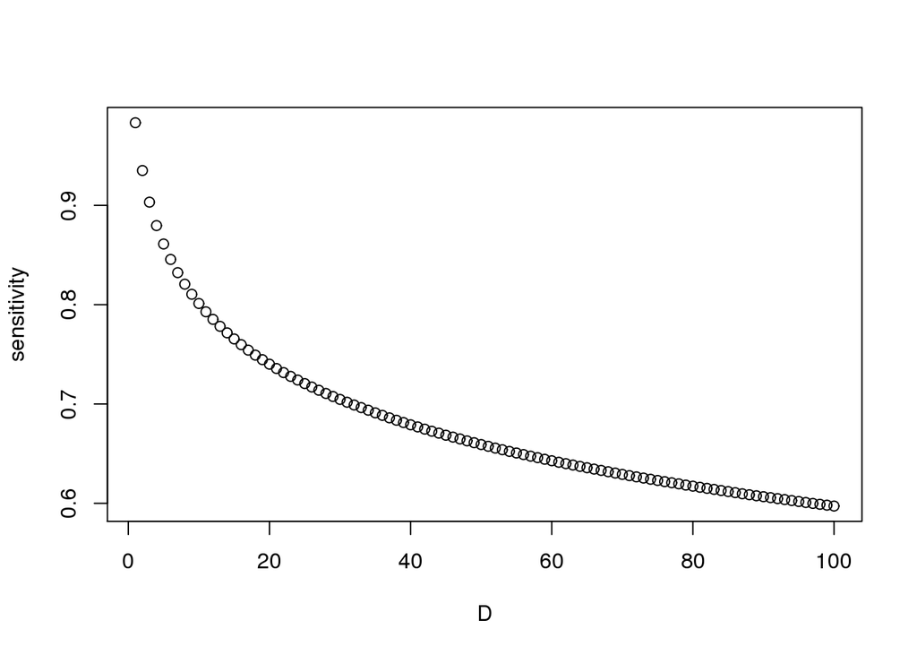

```r
dat <- tibble(
    D=seq(1,100),
    sensitivity=sapply(D, function(x)
    {
        r0_x <- r0 / x
        ctd_x <- est_ct(r0_x, Ed, rct)
        sum(ctd_x < ctthresh)/n
    })
)
plot(sensitivity ~ D, dat)
```

Save the parameter values for the model

```r
save(efficiency_params, Rct, file="../data/efficiency_params.rdata")
```